# Global COVID-19 Epidemiologic Data

For additional data and details please see this R package’s [GitHub repository](https://github.com/eebrown/data2019nCoV).

```r
library(data2019nCoV)

library(data.table)
library(tidyr)
library(dplyr)
library(ggplot2)
library(scales)

WHO_SR$Date[length(WHO_SR$Date)]
```

```
#> [1] "2020-04-21"
```

```r
sarscov2_ecdc_2019$date[length(sarscov2_ecdc_2019$date)]
```

```
#> [1] "2020-11-29"
```

This vignette visualizes data in the R package data2019nCoV, available on [GitHub](https://github.com/eebrown/data2019nCoV). Be sure to reinstall the package to use the latest data, via `devtools::install_github("eebrown/data2019nCoV")`.

The global data comes from 2 sources, the World Health Organization and the European CDC.

The data were manually extracted from the WHO [situation reports](https://www.who.int/emergencies/diseases/novel-coronavirus-2019/situation-reports) and stored in `raw-data/WHO_SR.csv`, which is loaded as the data frame `WHO_SR` in this package. This package uses freely available data, and itself is freely available with the CC0 licence. Information from WHO may be subject to WHO [copyright and terms](https://www.who.int/publishing/copyright/en/). The data source and package should be attributed. No warranty is made as to the accuracy of the data or transcription: use at your own risk. Please file an issue if you find any errors.

European CDC data was extracted by [Our World in Data](https://ourworldindata.org/coronavirus-source-data).

## Global Cases

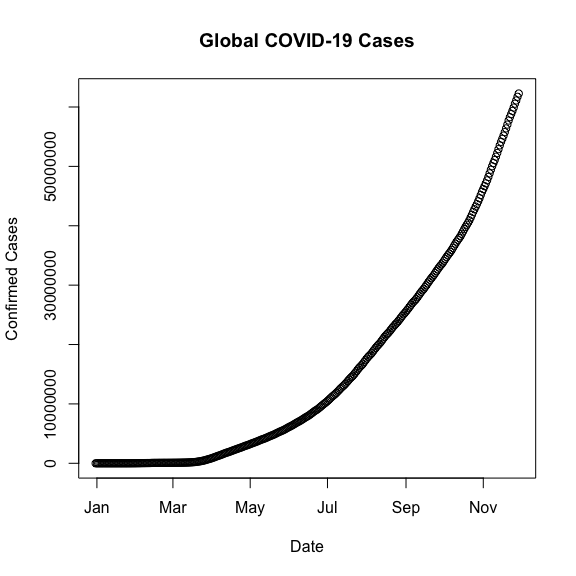

```r
# Global Cases
options(scipen=5)
#plot(WHO_SR$Date, WHO_SR$Global.confirmed,
#     main = "Global COVID-19 Cases",
#     xlab = "Date",
#     ylab = "Confirmed Cases",
#     type = "b")

plot(sarscov2_ecdc_2019$date, sarscov2_ecdc_2019$cases_global,
     main = "Global COVID-19 Cases",
     xlab = "Date",
     ylab = "Confirmed Cases",
     type = "b")
```

### New Daily Cases

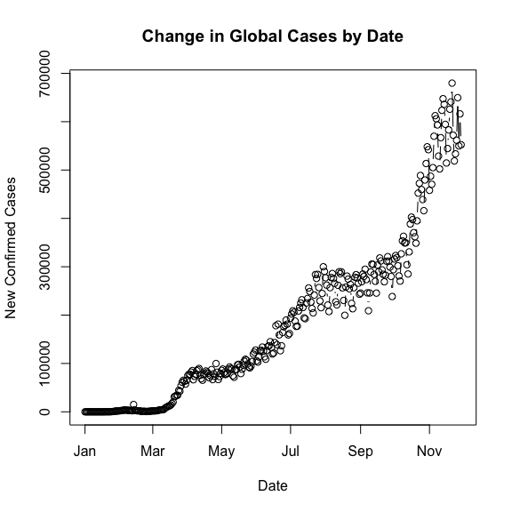

```r
# A function to calculate the daily change
daily_change <- function(series) {
  change <- c(series, NA) - c(NA, series)
  change <- change[-1]
  change <- change[-length(change)]
  return(change)
}

# Remove the change introduced with SR 27, when the definition was expanded.
change_cases <- daily_change(WHO_SR$Global.confirmed)
change_cases_ecdc <- daily_change(sarscov2_ecdc_2019$cases_global)

#plot(WHO_SR$Date[-1], change_cases,
#     main = "Change in Global Cases by Date",
#     ylab = "New Confirmed Cases",
#     xlab = "Date",
#     type = "b")

plot(sarscov2_ecdc_2019$date[-1], change_cases_ecdc,
     main = "Change in Global Cases by Date",
     ylab = "New Confirmed Cases",
     xlab = "Date",
     type = "b")
```

## Global Cases

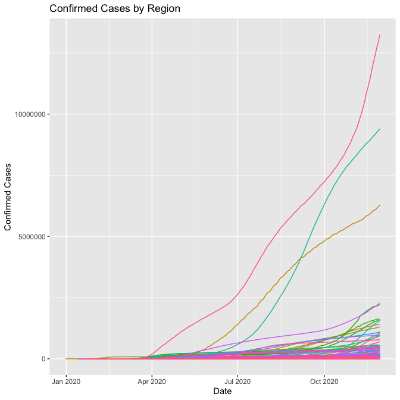

```r
# Every country
gather(sarscov2_ecdc_2019, key, value,

       cases_afg, cases_alb, cases_dza, cases_and, cases_ago, cases_aia, cases_atg, cases_arg, cases_arm, cases_abw, cases_aus, cases_aut, cases_aze, cases_bhs, cases_bhr, cases_bgd, cases_brb, cases_blr, cases_bel, cases_blz, cases_ben, cases_bmu, cases_btn, cases_bol, cases_bes, cases_bih, cases_bwa, cases_bra, cases_vgb, cases_brn, cases_bgr, cases_bfa, cases_bdi, cases_khm, cases_cmr, cases_can, cases_cpv, cases_cym, cases_caf, cases_tcd, cases_chl, cases_chn, cases_col, cases_cog, cases_cri, cases_civ, cases_hrv, cases_cub, cases_cuw, cases_cyp, cases_cze, cases_cod, cases_dnk, cases_dji, cases_dma, cases_dom, cases_ecu, cases_egy, cases_slv, cases_gnq, cases_eri, cases_est, cases_eth, cases_fro, cases_flk, cases_fji, cases_fin, cases_fra, cases_pyf, cases_gab, cases_gmb, cases_geo, cases_deu, cases_gha, cases_gib, cases_grc, cases_grl, cases_grd, cases_gum, cases_gtm, cases_ggy, cases_gin, cases_gnb, cases_guy, cases_hti, cases_hnd, cases_hun, cases_isl, cases_ind, cases_idn, cases_irn, cases_irq, cases_irl, cases_imn, cases_isr, cases_ita, cases_jam, cases_jpn, cases_jey, cases_jor, cases_kaz, cases_ken, cases_kosovo, cases_kwt, cases_kgz, cases_lao, cases_lva, cases_lbn, cases_lbr, cases_lby, cases_lie, cases_ltu, cases_lux, cases_mkd, cases_mdg, cases_mwi, cases_mys, cases_mdv, cases_mli, cases_mlt, cases_mrt, cases_mus, cases_mex, cases_mda, cases_mco, cases_mng, cases_mne, cases_msr, cases_mar, cases_moz, cases_mmr, cases_nam, cases_npl, cases_nld, cases_ncl, cases_nzl, cases_nic, cases_ner, cases_nga, cases_mnp, cases_nor, cases_omn, cases_pak, cases_xwb, cases_pan, cases_png, cases_pry, cases_per, cases_phl, cases_pol, cases_prt, cases_pri, cases_qat, cases_rou, cases_rus, cases_rwa, cases_kna, cases_lca, cases_vct, cases_smr, cases_stp, cases_sau, cases_sen, cases_srb, cases_syc, cases_sle, cases_sgp, cases_svk, cases_svn, cases_som, cases_zaf, cases_kor, cases_ssd, cases_esp, cases_lka, cases_sdn, cases_sur, cases_swz, cases_swe, cases_che, cases_syr, cases_twn, cases_tza, cases_tha, cases_tls, cases_tgo, cases_tto, cases_tun, cases_tur, cases_uga, cases_ukr, cases_are, cases_gbr, cases_usa, cases_vir, cases_ury, cases_uzb, cases_ven, cases_vnm, cases_yem, cases_zmb, cases_zwe) %>%
  ggplot(aes(x=date, y=value, col=key)) +
  geom_line() +
  theme(legend.position="none") +
  labs(title = "Confirmed Cases by Region",
       x = "Date",
       y = "Confirmed Cases") +
  theme(legend.title = element_blank())
```

# Chinese Provinces

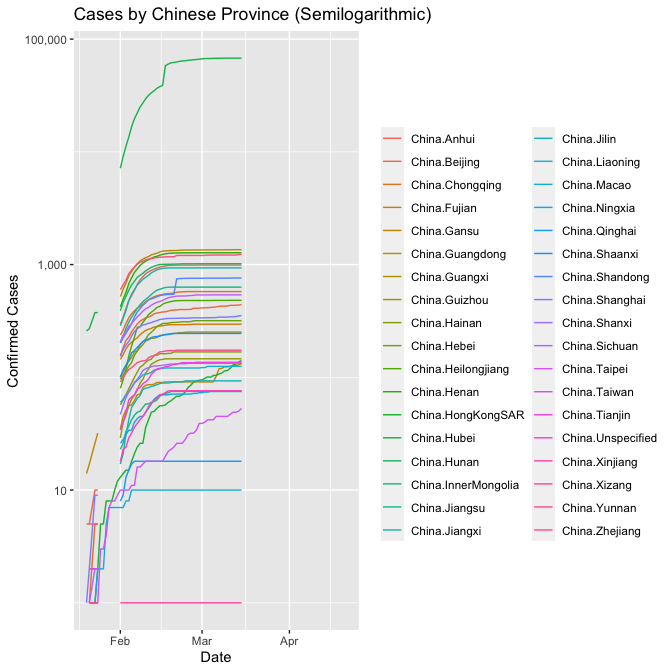

```r
gather(WHO_SR, key, value, China.Hubei,
       China.Guangdong, China.Beijing, China.Shanghai, China.Chongqing,
       China.Zhejiang, China.Jiangxi, China.Sichuan, China.Tianjin, China.Henan,
       China.Hunan, China.Shandong, China.Yunnan, China.Taiwan, China.Taipei,
       China.HongKongSAR, China.Macao, China.Unspecified, China.Anhui, China.Jiangsu,
       China.Fujian, China.Shaanxi, China.Guangxi, China.Hebei, China.Heilongjiang,
       China.Liaoning, China.Hainan, China.Shanxi, China.Gansu, China.Guizhou, China.Ningxia,
       China.InnerMongolia, China.Xinjiang, China.Jilin, China.Qinghai, China.Xizang) %>%
  ggplot(aes(x=Date, y=value, col=key)) +
  geom_line() +
  scale_y_continuous(trans = 'log10', labels = comma) +
  labs(title = "Cases by Chinese Province (Semilogarithmic)",
       x = "Date",
       y = "Confirmed Cases") +
  theme(legend.title = element_blank())
```

## Major Outbreaks

```r
# Major Outbreaks

# gather(sarscov2_ecdc_2019, key, value,
#        cases_chn,
#        cases_ita,
#        cases_irn,
#        cases_kor,
#        cases_esp,
#        cases_deu,
#        cases_fra,
#        cases_usa,
#        cases_che, #Switzerland,
#        cases_nld, #Netherlands,
#        cases_gbr, #UnitedKingdom,
#        cases_aut, #Austria
#        cases_tur,
#        ) %>%
#   ggplot(aes(x=date, y=value, col=key)) +
#   geom_line() +
#   theme(legend.position="right", legend.title = element_blank()) +
#   scale_y_continuous(trans = 'log10', labels = comma) +
#   labs(title = "Major COVID-19 Outbreaks (Semilogarithmic)",
#        x = "Date",
#        y = "Confirmed Cases")
#
 overx <- function(country, x) {
   over <- country[country > x]
   over <- c(over, rep(NA, length(WHO_SR$Date)))
   return(over)
 }

 start_no <- 100


# library(data.table)
#
# change_ita <- frollmean(daily_change(overx(sarscov2_ecdc_2019$cases_ita, start_no)) / 60461826, 7) *100000
# change_usa <- frollmean(daily_change(overx(sarscov2_ecdc_2019$cases_usa, start_no)) / 331002651, 7)*100000
# change_deu <- frollmean(daily_change(overx(sarscov2_ecdc_2019$cases_deu, start_no)) / 83783942, 7)*100000
# change_can <- frollmean(daily_change(overx(sarscov2_ecdc_2019$cases_can, start_no)) / 37742154, 7)*100000
#
# matplot(cbind(change_ita, change_usa, change_deu, change_can),
#         col=c("blue", "orange", "red", "green"), type="l",
#       xlab=paste0("Days since each region's 100th case"),
#       ylab= "Cases",
#       #main=paste0("Outbreak Progression from ", start_no, " Cases"),
#       xlim=c(0,80))
#      ylim=c(1000,700000))
# lines(change_usa, col="orange")
# lines(change_deu, col="red")
# lines(change_can, col="green")
# lines(overx(WHO_SR$Spain, start_no), col="brown")
# lines(overx(WHO_SR$Germany, start_no), col="coral")
# lines(overx(WHO_SR$France,  start_no), col="purple")
# lines(overx(WHO_SR$UnitedStatesofAmerica, start_no), col="blue")
# lines(overx(WHO_SR$Switzerland,  start_no), col="black")
# lines(overx(WHO_SR$Austria,  start_no), col="black")
# lines(overx(WHO_SR$UnitedKingdom,  start_no), col="cornflowerblue")
# lines(overx(WHO_SR$Netherlands, start_no), col="black")
# lines(overx(WHO_SR$Norway, start_no), col="black")
# lines(overx(WHO_SR$Sweden, start_no), col="black")
# lines(overx(WHO_SR$Denmark, start_no), col="black")
# lines(overx(WHO_SR$Belgium, start_no), col="black")
# lines(overx(WHO_SR$Canada, start_no), col="red")
#
# legend(x = "right", legend = c("USA", "Spain", "Germany",
#                                "Italy", "China", "UK",
#                                "France", "Iran", "Korea", "Canada"),
#        col =    c("blue", "brown",   "coral",
#                   "green", "gray", "cornflowerblue",
#                   "purple", "orange", "magenta", "red"),
#        pch=18)
```

### Outbreaks - Daily Cases

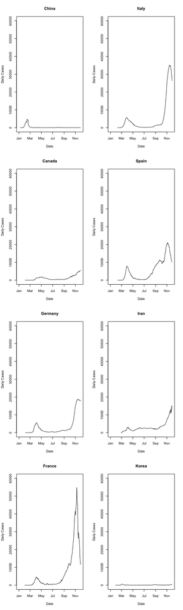

```r
outbreaks <- list(China = sarscov2_ecdc_2019$cases_chn,
                  Italy = sarscov2_ecdc_2019$cases_ita,
                  Canada = sarscov2_ecdc_2019$cases_can,
                  Spain = sarscov2_ecdc_2019$cases_esp,
                  Germany = sarscov2_ecdc_2019$cases_deu,
                  Iran = sarscov2_ecdc_2019$cases_irn,
                  France = sarscov2_ecdc_2019$cases_fra,
                  Korea = sarscov2_ecdc_2019$cases_kor)

par(mfrow=c(4,2))

for (i in 1:length(outbreaks)) {

 plot(sarscov2_ecdc_2019$date[-1], frollmean(daily_change(outbreaks[[i]]), 7),
      main = names(outbreaks)[[i]],
      ylab = "Daily Cases",
      xlab = "Date",
      type = "l",
      ylim = c(0,60000))
}
```

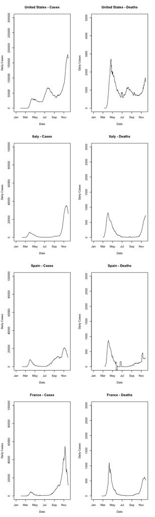

```r
 par(mfrow=c(4,2))

  plot(sarscov2_ecdc_2019$date[-1], frollmean(daily_change(sarscov2_ecdc_2019$cases_usa), 7),
       main = "United States - Cases",
       ylab = "Daily Cases",
       xlab = "Date",
       type = "l",
       ylim = c(0,300000))
 # lines(sarscov2_ecdc_2019$date[-1], frollmean(sarscov2_ecdc_2019$cases_usa, 7)[-1], col="green")

  plot(sarscov2_ecdc_2019$date[-1], frollmean(daily_change(sarscov2_ecdc_2019$deaths_usa), 7),
      main = "United States - Deaths",
      ylab = "Daily Cases",
      xlab = "Date",
      type = "l",
      ylim = c(0,5000))

   plot(sarscov2_ecdc_2019$date[-1], frollmean(daily_change(sarscov2_ecdc_2019$cases_ita), 7),
      main = "Italy - Cases",
      ylab = "Daily Cases",
      xlab = "Date",
      type = "l",
      ylim = c(0,100000))

    plot(sarscov2_ecdc_2019$date[-1], frollmean(daily_change(sarscov2_ecdc_2019$deaths_ita), 7),
      main = "Italy - Deaths",
      ylab = "Daily Cases",
      xlab = "Date",
      type = "l",
      ylim = c(0,3000))

     plot(sarscov2_ecdc_2019$date[-1], frollmean(daily_change(sarscov2_ecdc_2019$cases_esp), 7),
      main = "Spain - Cases",
      ylab = "Daily Cases",
      xlab = "Date",
      type = "l",
      ylim = c(0,100000))

      plot(sarscov2_ecdc_2019$date[-1], frollmean(daily_change(sarscov2_ecdc_2019$deaths_esp), 7),
      main = "Spain - Deaths",
      ylab = "Daily Cases",
      xlab = "Date",
      type = "l",
      ylim = c(0,3000))

      plot(sarscov2_ecdc_2019$date[-1], frollmean(daily_change(sarscov2_ecdc_2019$cases_fra), 7),
      main = "France - Cases",
      ylab = "Daily Cases",
      xlab = "Date",
      type = "l",
      ylim = c(0,100000))

      plot(sarscov2_ecdc_2019$date[-1], frollmean(daily_change(sarscov2_ecdc_2019$deaths_fra), 7),
      main = "France - Deaths",
      ylab = "Daily Cases",
      xlab = "Date",
      type = "l",
      ylim = c(0,3000))
```

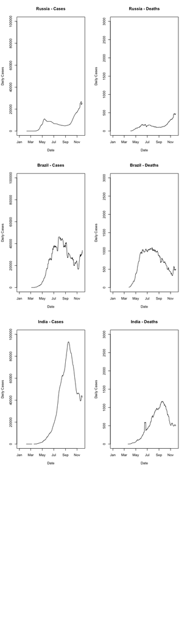

```r
      plot(sarscov2_ecdc_2019$date[-1], frollmean(daily_change(sarscov2_ecdc_2019$cases_rus), 7),
      main = "Russia - Cases",
      ylab = "Daily Cases",
      xlab = "Date",
      type = "l",
      ylim = c(0,100000))

      plot(sarscov2_ecdc_2019$date[-1], frollmean(daily_change(sarscov2_ecdc_2019$deaths_rus), 7),
      main = "Russia - Deaths",
      ylab = "Daily Cases",
      xlab = "Date",
      type = "l",
      ylim = c(0,3000))

            plot(sarscov2_ecdc_2019$date[-1], frollmean(daily_change(sarscov2_ecdc_2019$cases_bra), 7),
      main = "Brazil - Cases",
      ylab = "Daily Cases",
      xlab = "Date",
      type = "l",
      ylim = c(0,100000))

      plot(sarscov2_ecdc_2019$date[-1], frollmean(daily_change(sarscov2_ecdc_2019$deaths_bra), 7),
      main = "Brazil - Deaths",
      ylab = "Daily Cases",
      xlab = "Date",
      type = "l",
      ylim = c(0,3000))

      plot(sarscov2_ecdc_2019$date[-1], frollmean(daily_change(sarscov2_ecdc_2019$cases_ind), 7),
      main = "India - Cases",
      ylab = "Daily Cases",
      xlab = "Date",
      type = "l",
      ylim = c(0,100000))

      plot(sarscov2_ecdc_2019$date[-1], frollmean(daily_change(sarscov2_ecdc_2019$deaths_ind), 7),
      main = "India - Deaths",
      ylab = "Daily Cases",
      xlab = "Date",
      type = "l",
      ylim = c(0,3000))
```

## Deaths

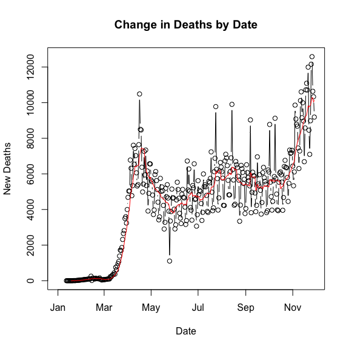

```r
# Change in Cases Between Reports
plot(sarscov2_ecdc_2019$date[-1], daily_change(sarscov2_ecdc_2019$deaths_global),
     main = "Change in Deaths by Date",
     ylab = "New Deaths",
     xlab = "Date",
     type = "b")
lines(sarscov2_ecdc_2019$date[-1],
frollmean(daily_change(sarscov2_ecdc_2019$deaths_global), 7), col="red")
```

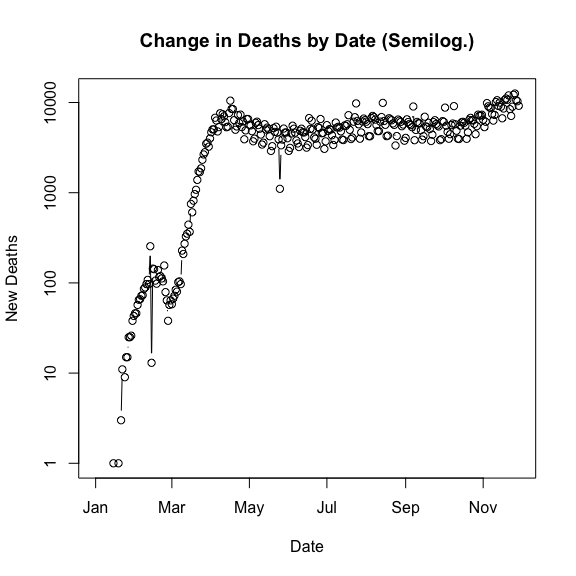

```r
plot(sarscov2_ecdc_2019$date[-1], daily_change(sarscov2_ecdc_2019$deaths_global),
     main = "Change in Deaths by Date (Semilog.)",
     ylab = "New Deaths",
     xlab = "Date",
     type = "b",
     log = "y")
```

### Case Fatality Rate

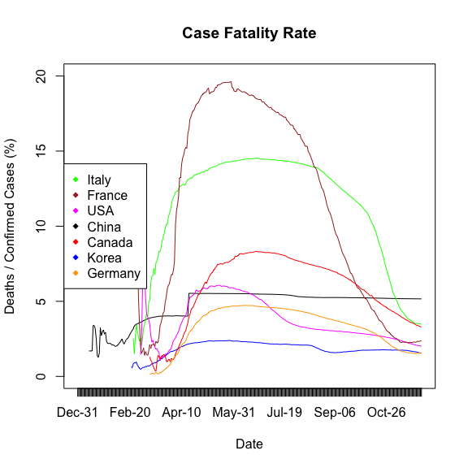

```r
matplot(as.Date(sarscov2_ecdc_2019$date), cbind(
                      (sarscov2_ecdc_2019$deaths_chn / sarscov2_ecdc_2019$cases_chn)*100,
                      (sarscov2_ecdc_2019$deaths_kor / sarscov2_ecdc_2019$cases_kor)*100,
                      (sarscov2_ecdc_2019$deaths_ita / sarscov2_ecdc_2019$cases_ita)*100,
                      (sarscov2_ecdc_2019$deaths_usa / sarscov2_ecdc_2019$cases_usa)*100,
                      (sarscov2_ecdc_2019$deaths_can / sarscov2_ecdc_2019$cases_can)*100,
                      (sarscov2_ecdc_2019$deaths_fra / sarscov2_ecdc_2019$cases_fra)*100,
                      (sarscov2_ecdc_2019$deaths_deu / sarscov2_ecdc_2019$cases_deu)*100),
     main = "Case Fatality Rate",
     xlab = "Date",
     ylab = "Deaths / Confirmed Cases (%)",
     type = "l",
     lty = "solid",
     col = c("black",   "blue",  "green", "magenta", "red", "brown", "orange"),
     ylim = c(0,20),
     xaxt="n")
dates<-format(sarscov2_ecdc_2019$date,"%b-%d")
axis(1, at=sarscov2_ecdc_2019$date, labels=dates)
legend(x="left",
       legend = c("Italy", "France", "USA", "China", "Canada", "Korea", "Germany"),
       col =    c("green", "brown", "magenta", "black", "red", "blue", "orange"),
       pch=18)
```

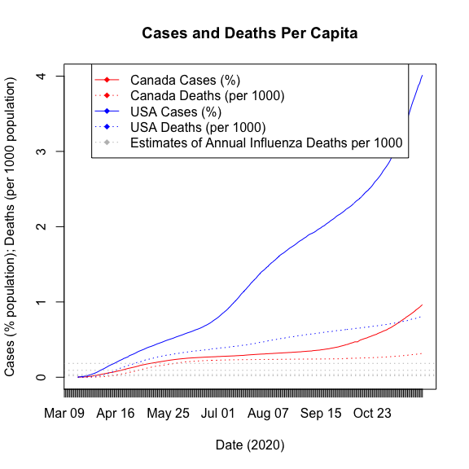

```r
population_US <- 329968629
population_CAN <- 37894799

range <- 80:length(sarscov2_ecdc_2019$cases_can)

matplot(as.Date(sarscov2_ecdc_2019$date[range]), cbind(
                           ( (sarscov2_ecdc_2019$cases_can / population_CAN)[range] * 100 ),
                           ( (sarscov2_ecdc_2019$deaths_can / population_CAN)[range] * 1000 ),
                           ( (sarscov2_ecdc_2019$cases_usa / population_US)[range] * 100 ),
                           ( (sarscov2_ecdc_2019$deaths_usa / population_US)[range] * 1000 )
                           ),

     main = "Cases and Deaths Per Capita",
     xlab = "Date (2020)",
     ylab = "Cases (% population); Deaths (per 1000 population)",
     type = "l",
     col = c("red",   "red",  "blue", "blue"),
     lty = c("solid", "dotted", "solid", "dotted"),
     ylim = c(0,4),
     ylog = TRUE,
     xaxt="n")
dates<-format(sarscov2_ecdc_2019$date,"%b %d")
axis(1, at=sarscov2_ecdc_2019$date, labels=dates)
legend(x="top",
       legend = c("Canada Cases (%)", "Canada Deaths (per 1000)", "USA Cases (%)", "USA Deaths (per 1000)", "Estimates of Annual Influenza Deaths per 1000"),
       col =    c("red",   "red",  "blue", "blue", "grey"),
       lty = c("solid", "dotted", "solid", "dotted", "dotted"),
       pch=18)
#annual mortality from influenza per thousand (https://ipac-canada.org/influenza-resources.php)
abline(h = .020, col="grey", lty="dotted")
#lower and upper annual mortality from influenza per thousand (CDC)
abline(h = .036, col="grey", lty="dotted")
abline(h = .184, col="grey", lty="dotted")
# (https://www.ontario.ca/page/flu-facts)
abline(h = .092, col="grey", lty="dotted")
```